# Property_Data

I found two sources of property data for my local county. Each dataset contains fields that are similar and some that are not, if there are enough similar fields I can create a key using the most minimal number of fields for each parcel and then compare the data collected in each data set. Luckily for me parcels of land have ids, addresses and owners and each of these tables have those fields, they are just formatted differently. Once I have identified unique parcels I can begin comparing fields that are MEANT to contain the same data for that parcel.

```python
#importing and querying tables
from simpledbf import Dbf5
import pandas as pd
import numpy as np
import re

#Getting data from the internet
import requests

#easy gis
import folium
from folium import plugins

#Exploratory Analysis
import matplotlib.pyplot as plt
import matplotlib.gridspec as gridspec
import seaborn as sns; sns.set()

#this is a local class that I swipped from stack excahnge
#https://stackoverflow.com/questions/35042255/how-to-plot-multiple-seaborn-jointplot-in-subplot
from SeabornFig2Grid import SeabornFig2Grid

#Create pretty tables and dramatic loading bars to make coding even more fun
from prettytable import PrettyTable
from tqdm import tqdm
```

```python
#https://www.buncombecounty.org/governing/depts/gis/download-digital-data.aspx
away_path = 'C:/Users/nhodges/Data/EstateData/'
home_path = 'D:/Data/webprcls/'
dbf = Dbf5(home_path + 'property.dbf')
df1 = dbf.to_dataframe()

#https://tax.buncombecounty.org/download/Search.aspx
df2 = pd.read_csv(home_path + 'WebPrcls.csv', low_memory = False, keep_default_na=False)
```

```python
df1.columns
```

```
Index(['pinnum', 'pin', 'pinext', 'owner', 'nmptype', 'TaxYear', 'CondoUnit',
       'CondoBuild', 'DeedBook', 'DeedPage', 'PlatBook', 'PlatPage', 'SubName',
       'SubLot', 'SubBlock', 'SubSect', 'UpdateDate', 'HouseNumbe',
       'NumberSuff', 'direction', 'streetname', 'StreetType', 'Township',
       'Acreage', 'AccountNum', 'DeedDate', 'Stamps', 'Instrument', 'Reason',
       'County', 'City', 'FireDistri', 'SchoolDist', 'CareOf', 'Address',
       'CityName', 'State', 'Zipcode', 'Class', 'Improved', 'Exempt', 'Priced',
       'TotalMarke', 'AppraisedV', 'TaxValue', 'LandUse', 'Neighborho',
       'LandValue', 'BuildingVa', 'Improvemen', 'AppraisalA', 'PostDirect',
       'SalePrice', 'propcard', 'shape_STAr', 'shape_STLe'],
      dtype='object')
```

```python
df1.head(1)
```

|  | pinnum | pin | pinext | owner | nmptype | TaxYear | CondoUnit | CondoBuild | DeedBook | DeedPage | ... | Neighborho | LandValue | BuildingVa | Improvemen | AppraisalA | PostDirect | SalePrice | propcard | shape_STAr | shape_STLe |
| --- | --- | --- | --- | --- | --- | --- | --- | --- | --- | --- | --- | --- | --- | --- | --- | --- | --- | --- | --- | --- | --- |
| 0 | 060502683700000 | 0605026837 | 00000 | MANLY DAVID T;DILLON MARGARET | 0 | 20 | NaN | NaN | 4879 | 0206 | ... | SUOA | 120000 | 345700 | 3000 | 5 | NaN | 125000.0 | http://www.buncombetax.org/GIS.aspx?type=card&... | 59254.188965 | 929.26914 |

1 rows × 56 columns

```python
df2.columns
```

```
Index(['parcel_id', 'active_flag', 'owner1_last_name', 'owner1_first_name',
       'owner1_third_name', 'owner1_suffix_name', 'owner2_last_name',
       'owner2_first_name', 'owner2_third_name', 'owner2_suffix_name',
       'owner_address_line1', 'owner_address_line2', 'owner_city',
       'owner_state', 'owner_zip1', 'owner_zip2', 'house_num', 'house_suf',
       'street_direction', 'street_name', 'street_type', 'street_suffix',
       'apt_unit', 'subdivision', 'sub_lot', 'township', 'city_code',
       'fire_code', 'schl_code', 'plat_book', 'plat_page', 'deed_book',
       'deed_page', 'deed_date', 'deed_instrument', 'acres', 'class',
       'neighborhood', 'land_val', 'bldg_val', 'impr_val', 'dfrd_val',
       'exempt_code', 'exempt_val', 'taxable_val'],
      dtype='object')
```

```python
df2.head(1)
```

|  | parcel_id | active_flag | owner1_last_name | owner1_first_name | owner1_third_name | owner1_suffix_name | owner2_last_name | owner2_first_name | owner2_third_name | owner2_suffix_name | ... | acres | class | neighborhood | land_val | bldg_val | impr_val | dfrd_val | exempt_code | exempt_val | taxable_val |
| --- | --- | --- | --- | --- | --- | --- | --- | --- | --- | --- | --- | --- | --- | --- | --- | --- | --- | --- | --- | --- | --- |
| 0 | 9649-10-5680-00000 | 1 | MOUNTAIN CREDIT UNION FKA AFE CREDIT UNION |  |  |  |  |  |  |  | ... | 0.48 | OFFICE BLDG | CENTRAL BUS. FRINGE | 198600 | 225900 | 0 | 0 |  | 0 | 424500 |

1 rows × 45 columns

df1 has one column for owner, df2 has columns for each part of the name of each owner. I like the idea of one column for owner name becuase I would like to use this column as a key for all of the data. So I will make a column in df2 that combines the columns of names. df1 also appears to have parcel ids that are not in the same format as df2 so I will change it to df2's format.

```python
#New column for df2
df2['owner_df2'] = df2['owner1_last_name']  + ' ' + df2['owner1_first_name']  + ' ' +\
                   df2['owner1_third_name'] + ' ' + df2['owner1_suffix_name'] + ';' +\
                   df2['owner2_last_name']  + ' ' + df2['owner2_first_name']  + ' ' +\
                   df2['owner2_third_name'] + ' ' + df2['owner2_suffix_name']

#matching the formats of both data sets for owner names
A1 = df1.owner
A1 = A1.map(lambda x : x.replace(';', ' '))
A1 = A1.map(lambda x: re.sub(' +', ' ', x))
A1 = A1.map(lambda x: x.strip())
df1.owner = A1

A2 = df2.owner_df2
A2 = A2.map(lambda x: x.replace(';', ' '))
A2 = A2.map(lambda x: re.sub(' +', ' ', x))
A2 = A2.map(lambda x: x.strip())
df2.owner_df2 = A2

#formatting pacel id column for df1
df1.pinnum = df1.pinnum.apply(lambda x: '-'.join((x[0:4],x[4:6],x[6:10],x[10:])))

#drop the old columns
df1 = df1.drop(['pin','pinext'], axis = 1)

df2 = df2.drop(['owner1_last_name','owner1_first_name','owner1_third_name','owner1_suffix_name',\
                'owner2_last_name','owner2_first_name','owner2_third_name','owner2_suffix_name'], axis = 1)
```

```python
df1.head(1)
```

|  | pinnum | owner | nmptype | TaxYear | CondoUnit | CondoBuild | DeedBook | DeedPage | PlatBook | PlatPage | ... | Neighborho | LandValue | BuildingVa | Improvemen | AppraisalA | PostDirect | SalePrice | propcard | shape_STAr | shape_STLe |
| --- | --- | --- | --- | --- | --- | --- | --- | --- | --- | --- | --- | --- | --- | --- | --- | --- | --- | --- | --- | --- | --- |
| 0 | 0605-02-6837-00000 | MANLY DAVID T DILLON MARGARET | 0 | 20 | NaN | NaN | 4879 | 0206 | 0104 | 0149 | ... | SUOA | 120000 | 345700 | 3000 | 5 | NaN | 125000.0 | http://www.buncombetax.org/GIS.aspx?type=card&... | 59254.188965 | 929.26914 |

1 rows × 54 columns

```python
df2.head(1)
```

|  | parcel_id | active_flag | owner_address_line1 | owner_address_line2 | owner_city | owner_state | owner_zip1 | owner_zip2 | house_num | house_suf | ... | class | neighborhood | land_val | bldg_val | impr_val | dfrd_val | exempt_code | exempt_val | taxable_val | owner_df2 |
| --- | --- | --- | --- | --- | --- | --- | --- | --- | --- | --- | --- | --- | --- | --- | --- | --- | --- | --- | --- | --- | --- |
| 0 | 9649-10-5680-00000 | 1 | 38 MAPLE ST |  | WAYNESVILLE | NC | 28786 | 5764 | 219 |  | ... | OFFICE BLDG | CENTRAL BUS. FRINGE | 198600 | 225900 | 0 | 0 |  | 0 | 424500 | MOUNTAIN CREDIT UNION FKA AFE CREDIT UNION |

1 rows × 38 columns

Below is a quick stradegy I created to compare fields to determine if they have similar data(not just the same data type). I use a list of all possible pairs of columns and find all of the unique elements in each. The value calculated is the ratio of intersection to the total number of elements in each list. I then scale this by two so that 1 is a perfect score.

This method will only suggest columns that have the same data, but it can easily be misleading. If two columns were categorical in nature encoded with integers or had the same data but representing different topics. Then it will show a good score, the method is only supposed to suggest similar data, not recommend that they do in fact represent the SAME data. However, when two columns appear to have the same data and they have column names that suggest the same source of the data then it may mean that the two columns are suppose to measure the same data.

A good example for these datasets would be TaxValue in df1 vesus taxable_val in df2 or FireDistri in df1 versus fire_code in df2. You could go through each column and with enough subject matter speaicality decide if two columns measure the same data, but if you are not a SME, like myself it helps to have a program suggest like columns.

```python
pairs = [[x,y] for x in df1.columns for y in df2.columns]

t = PrettyTable(['Columns', 'Percent','Size of Intersection'])

for pair in tqdm(pairs, mininterval = 0.5, ascii = False):
    a = df1[pair[0]].unique()
    b = df2[pair[1]].unique()
    inter = set(a).intersection(set(b))

    value = 2*len(inter)/(len(a)+len(b))

    if value > 0.6:
        t.add_row([pair, round(value,2), len(inter)])
    else:
        pass

t.sortby = "Percent"
t.reversesort = True
print(t)
```

```
+------------------------------------+---------+----------------------+
|              Columns               | Percent | Size of Intersection |
+------------------------------------+---------+----------------------+
|   ['streetname', 'street_name']    |   1.0   |         7343         |
|     ['PlatPage', 'plat_page']      |   1.0   |         328          |
|     ['DeedPage', 'deed_page']      |   1.0   |         2079         |
|     ['DeedBook', 'deed_book']      |   1.0   |         5377         |
|       ['owner', 'owner_df2']       |   0.99  |        96465         |
|     ['Zipcode', 'owner_zip1']      |   0.99  |         4748         |
|     ['PlatBook', 'plat_book']      |   0.99  |         243          |
|    ['TaxValue', 'taxable_val']     |   0.98  |        11220         |
|   ['StreetType', 'street_type']    |   0.98  |          54          |
|      ['State', 'owner_state']      |   0.98  |          59          |
|     ['Improvemen', 'impr_val']     |   0.98  |         795          |
|     ['BuildingVa', 'bldg_val']     |   0.98  |         9236         |
|   ['AppraisedV', 'taxable_val']    |   0.98  |        11220         |
|   ['TotalMarke', 'taxable_val']    |   0.97  |        11198         |
|      ['pinnum', 'parcel_id']       |   0.96  |        126706        |
|      ['Township', 'township']      |   0.96  |          27          |
| ['Instrument', 'deed_instrument']  |   0.96  |          26          |
| ['Address', 'owner_address_line1'] |   0.96  |        77399         |
|     ['LandValue', 'land_val']      |   0.94  |         5626         |
|     ['CityName', 'owner_city']     |   0.92  |         2700         |
|       ['City', 'city_code']        |   0.86  |          6           |
|     ['nmptype', 'active_flag']     |   0.8   |          2           |
| ['direction', 'street_direction']  |   0.77  |          5           |
|  ['PostDirect', 'street_suffix']   |   0.77  |          5           |
|    ['FireDistri', 'fire_code']     |   0.75  |          20          |
|     ['TotalMarke', 'bldg_val']     |   0.71  |         7458         |
|      ['TaxValue', 'bldg_val']      |   0.71  |         7403         |
|   ['BuildingVa', 'taxable_val']    |   0.71  |         7387         |
|     ['AppraisedV', 'bldg_val']     |   0.71  |         7403         |
|     ['PlatPage', 'plat_book']      |   0.7   |         201          |
|     ['PlatBook', 'plat_page']      |   0.7   |         201          |
|      ['Stamps', 'house_num']       |   0.69  |         1748         |
|     ['DeedBook', 'owner_zip2']     |   0.67  |         4692         |
|     ['BuildingVa', 'land_val']     |   0.65  |         5018         |
|     ['TotalMarke', 'land_val']     |   0.63  |         5536         |
|      ['TaxValue', 'land_val']      |   0.63  |         5486         |
|     ['AppraisedV', 'land_val']     |   0.63  |         5486         |
|   ['direction', 'street_suffix']   |   0.62  |          4           |
| ['PostDirect', 'street_direction'] |   0.62  |          4           |
|     ['LandValue', 'bldg_val']      |   0.61  |         4656         |
+------------------------------------+---------+----------------------+
```

```python
#renaming fields that are alike to easily reference between datasets
df1 = df1.rename(index = str, columns = {'BuildingVa':'bldg_val_df1','LandValue':'land_val_df1',
                                         'Acreage':'acres_df1','Class' :'class_df1',
                                         'owner':'owner_df1', 'SubLot': 'SubLot_df1' ,
                                         'pinnum':'parcel_id_df1','Exempt':'exempt_code_df1',
                                         'SchoolDist':'schl_code_df1', 'Improvemen':'impr_val_df1',
                                         'TaxValue': 'tax_val_df1','DeedBook': 'deed_book_df1',
                                         'DeedPage': 'deed_pg_df1','Township': 'township_df1',
                                         'Instrument': 'deed_instrument_df1','City': 'city_code_df1',
                                         'PlatBook': 'plat_book_df1','FireDistri': 'fire_code_df1',
                                         'streetname': 'street_name_df1','Zipcode':'zipcode_df1',
                                         'PlatPage': 'plat_pg_df1'
                                        })

df2 = df2.rename(index = str, columns = {'bldg_val':'bldg_val_df2','land_val':'land_val_df2',
                                         'acres' :'acres_df2', 'class':'class_df2',
                                         'sub_lot':'SubLot_df2','parcel_id':'parcel_id_df2',
                                         'exempt_code':'exempt_code_df2','schl_code':'schl_code_df2',
                                         'impr_val':'impr_val_df1', 'taxable_val':'tax_val_df2',
                                         'deed_book':'deed_book_df2', 'deed_page':'deed_pg_df2',
                                         'township':'township_df2','deed_instrument':'deed_instrument_df2',
                                         'city_code':'city_code_df2','plat_book':'plat_book_df2',
                                         'fire_code':'fire_code_df2','street_name': 'street_name_df2',
                                         'owner_zip1':'zipcode_df2','plat_page':'plat_pg_df2'
                                        })
```

Let's see how many owners have the same name from each dataframe. We can tell based on the owner names that match so far that we have a different number of properites in each dataset. This could be due to a small error in the name or actually because of different property information.

```python
df1.owner_df1.value_counts().head(10)
```

```
CITY OF ASHEVILLE                                                365
URBANA CLIFFS RE LLC                                             229
STARS & STRIPES 4E LLC                                           188
BUNCOMBE COUNTY                                                  110
CANTERBURY ACQUISITION LLC                                       106
BILTMORE LAKE ASSOCIATION INC                                    102
CANE CREEK VISTAS LLC                                             86
BUNCOMBE COUNTY BOARD OF EDUCATION                                82
PROGRESS ENERGY OF THE CAROLINAS FKA CAROLINA POWER AND LIGHT     79
MOUNTAIN RETREAT ASSOC                                            78
Name: owner_df1, dtype: int64
```

```python
df2.owner_df2.value_counts().head(10)
```

```
CITY OF ASHEVILLE                     409
URBANA CLIFFS RE LLC                  279
STARS & STRIPES 4E LLC                188
BUNCOMBE COUNTY                       120
CANE CREEK VISTAS LLC                 111
CANTERBURY ACQUISITION LLC            106
BILTMORE LAKE ASSOCIATION INC         102
REDUS NC-ALL LLC                       99
LIFEWAY CHRISTIAN RESOURCES            96
BUNCOMBE COUNTY BOARD OF EDUCATION     96
Name: owner_df2, dtype: int64
```

```python
#number of duplicate parcel ids
len(df2.parcel_id_df2) - len(df2.parcel_id_df2.unique())
```

```
0
```

```python
#number of duplicate parcel ids
len(df1.parcel_id_df1) -len(df1.parcel_id_df1.unique())
```

```
0
```

This is great! There aren't any duplicate pacel ids so we can be confident in using these as real property keys. Now we would like to know what properites are accounted for in both data sets and which are unique to one or the other. We can remove the properites that do not overlap and create a new table to study them further if we want to.

```python
set1 = set(df1.parcel_id_df1)
set2 = set(df2.parcel_id_df2)

print(len(set1.difference(set2)),' property ids in df1, but not in df2.')

print(len(set2.difference(set1)),' property ids in df2, but not in df1.')
```

```
1  property ids in df1, but not in df2.
9696  property ids in df2, but not in df1.
```

```python
df1 = df1[df1.parcel_id_df1.isin(list(set2.intersection(set1)))]
df2 = df2[df2.parcel_id_df2.isin(list(set2.intersection(set1)))]
```

So out of ~ 120k parcel ids only ~10,000 are in df1 or df2 exclusively. That's not bad we are still left with a lot of properties that we are almost ready to merge. The next step would be to show that the parcel id with the owner name matches both datasets.

```python
df1['key1'] = df1['parcel_id_df1'] +' ' + df1['owner_df1']
df2['key2'] = df2['parcel_id_df2'] +' ' + df2['owner_df2']

set1 = set(df1.key1)
set2 = set(df2.key2)

print(len(set1.difference(set2)),' keys do not overlap.')
```

```
878  keys do not overlap.
```

```python
df2 = df2[df2.key2.isin(list(set1.intersection(set2)))]
df1 = df1[df1.key1.isin(list(set1.intersection(set2)))]

df1 = df1.set_index(keys = 'key1')
df2 = df2.set_index(keys = 'key2')

result = pd.concat([df1, df2], axis=1, sort=False)
result = result.reset_index()

result.shape
```

```
(125828, 93)
```

By plotting similar columns against one another we can tell right away the severity of any discrepancies. We would expect that if two columns represent the same data then plotting one against the other should produce the line y = x. What we see below is that in df1 parcels were most likely given a 0 value when the information was not known, if we trusted df2 then we could actually fill in these missing values. For my purposes though I will discredit these instances since I already have so many parcels to work with.

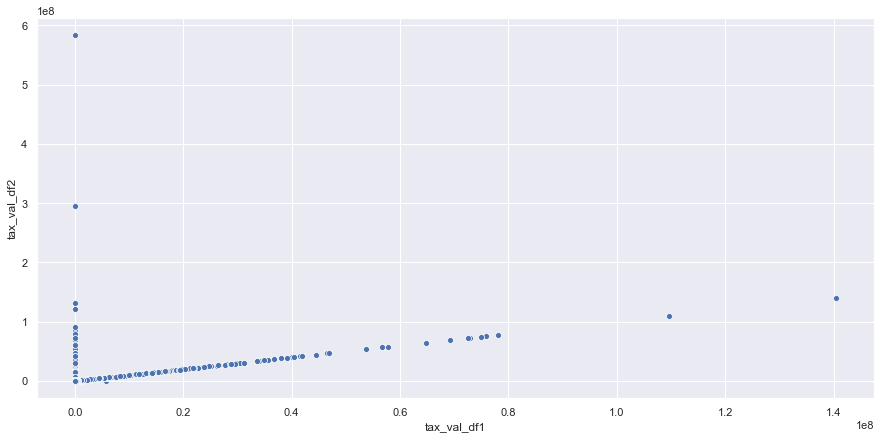

```python
ax,fig = plt.subplots(figsize = (15,7))
cols = ['tax_val_df1','tax_val_df2']
sns.scatterplot(data = result[cols], x = cols[0], y = cols[1])
plt.show()
```

Below we can see that at a max we have ~15,000 data points that do not match. That leaves us with 100k homes with the same parcel_id, owner name, street name, acres and building, land and tax value. After that number of matches I am confident to start doing some analysis on the data that is left.

```python
#function to compare columns of same type
def comp_2(clist, df, error):
    x, y = clist[0], clist[1]
    try:
        out = df[abs(df[x] - df[y]) > error]
    except:
        out = df[df[x] != df[y]]

    print('DF size:',len(df) ,'/Count One: ',df[x].count(),'/Count Two: ',df[y].count() ,'/Count Discrepancies: ',len(out[[x,y]]))

    return list(out[[x,y]].index)
```

```python
#I would be willing to let these go, and round column 1, but there is a descrepancy!
comp = ['acres_df1','acres_df2']
print(comp[0],comp[1])
ftr1 = comp_2(clist=comp, df = result, error =  10**-5)
```

```
acres_df1 acres_df2
DF size: 125828 /Count One:  125828 /Count Two:  125828 /Count Discrepancies:  32
```

```python
#I am willing to believe that zeros were entered inplace of not having the data, but given the size of the data set
#I would say that getting rid of these would not hurt.

comp = ['bldg_val_df1','bldg_val_df2']
print(comp[0],comp[1])
ftr2 = comp_2(clist = comp, df = result, error = 0)
```

```
bldg_val_df1 bldg_val_df2
DF size: 125828 /Count One:  125828 /Count Two:  125828 /Count Discrepancies:  3606
```

```python
#comparing street names
comp = ['street_name_df1','street_name_df2']
print(comp[0],comp[1])
ftr3 = comp_2(comp, result, error = None)
```

```
street_name_df1 street_name_df2
DF size: 125828 /Count One:  125828 /Count Two:  125828 /Count Discrepancies:  8
```

```python
#another oddity
comp = ['tax_val_df1','tax_val_df2']
print(comp[0],comp[1])
ftr4 = comp_2(comp, result, error = 00)
```

```
tax_val_df1 tax_val_df2
DF size: 125828 /Count One:  125828 /Count Two:  125828 /Count Discrepancies:  4836
```

```python
#difference in land values
comp = ['land_val_df1','land_val_df2']
print(comp[0],comp[1])
ftr5 = comp_2(comp, result, error = 0)
```

```
land_val_df1 land_val_df2
DF size: 125828 /Count One:  125828 /Count Two:  125828 /Count Discrepancies:  6655
```

```python
#ftrx are features that I want to make sure are not present when doing any analysis
idx_delete = ftr1+ftr2+ftr3+ftr4+ftr5
result = result[~result.index.isin(idx_delete)]
```

```python
result = result.dropna(subset = ['house_num', 'street_name_df2', 'street_type'])
result['address'] = result["house_num"].map(str) + '+' + result["street_name_df1"].str.replace(" ", "+") + '+' + result["street_type"] + '+Asheville+NC'
```

```python
result = result.loc[:,~result.columns.duplicated()]
```

```python
result.shape
```

```
(118969, 93)
```

Now what I want to do is get rid of columns with duplicate data. Since I have filtered the data to only show parcels that were in strict agreement with parcel id, owner, tax value, land value, building value, acres and street name I am confident in dropping the df1 df2 nomenclature and I will use these fields for subsequent analysis. The next step I would like to take is geocoding the addresses so that information on each parcel can be translated into data that is location dependent and I can make pretty graphs! So the following loop makes requests to the US Census geocoding api. It will not be able to find all longitude and latitude for each parcel so that will filter the data even more.

```python
result = result[0:100]
lat = []
lon = []
for index, row in tqdm(result.iterrows(), total=result.shape[0]):
    address = row.address
    try:
        r = requests.get('https://geocoding.geo.census.gov/geocoder/locations/onelineaddress?address=' + address +'&benchmark=Public_AR_Census2010&format=json')
        coord = r.json()['result']['addressMatches'][0]['coordinates']
        lon.append(coord['x'])
        lat.append(coord['y'])
    except:
        lat.append(None)
        lon.append(None)

result['lat'] = lat
result['lon'] = lon
result = result.dropna(subset = ['lat','lon'])
```

```python
result.columns
```

```
Index(['index', 'parcel_id_df1', 'owner_df1', 'nmptype', 'TaxYear',
       'CondoUnit', 'CondoBuild', 'deed_book_df1', 'deed_pg_df1',
       'plat_book_df1', 'plat_pg_df1', 'SubName', 'SubLot_df1', 'SubBlock',
       'SubSect', 'UpdateDate', 'HouseNumbe', 'NumberSuff', 'direction',
       'street_name_df1', 'StreetType', 'township_df1', 'acres_df1',
       'AccountNum', 'DeedDate', 'Stamps', 'deed_instrument_df1', 'Reason',
       'County', 'city_code_df1', 'fire_code_df1', 'schl_code_df1', 'CareOf',
       'Address', 'CityName', 'State', 'zipcode_df1', 'class_df1', 'Improved',
       'exempt_code_df1', 'Priced', 'TotalMarke', 'AppraisedV', 'tax_val_df1',
       'LandUse', 'Neighborho', 'land_val_df1', 'bldg_val_df1', 'impr_val_df1',
       'AppraisalA', 'PostDirect', 'SalePrice', 'propcard', 'shape_STAr',
       'shape_STLe', 'parcel_id_df2', 'active_flag', 'owner_address_line1',
       'owner_address_line2', 'owner_city', 'owner_state', 'zipcode_df2',
       'owner_zip2', 'house_num', 'house_suf', 'street_direction',
       'street_name_df2', 'street_type', 'street_suffix', 'apt_unit',
       'subdivision', 'SubLot_df2', 'township_df2', 'city_code_df2',
       'fire_code_df2', 'schl_code_df2', 'plat_book_df2', 'plat_pg_df2',
       'deed_book_df2', 'deed_pg_df2', 'deed_date', 'deed_instrument_df2',
       'acres_df2', 'class_df2', 'neighborhood', 'land_val_df2',
       'bldg_val_df2', 'dfrd_val', 'exempt_code_df2', 'exempt_val',
       'tax_val_df2', 'owner_df2', 'address', 'lat', 'lon'],
      dtype='object')
```

```python
data_cols = ['parcel_id_df1','owner_df1',
             'tax_val_df1','land_val_df1','acres_df1',
             'SalePrice','DeedDate','Neighborho',
             'lat','lon','shape_STAr','shape_STLe'
            ]
data = result[data_cols]

#renaming fields that are alike to easily reference between datasets
data = data.rename(index = str, columns = {'parcel_id_df1':'id','owner_df1':'owner',
                                           'tax_val_df1':'tax','land_val_df1':'land',
                                           'acres_df1':'acres','Neighborho':'neigh'
                                          })
data = data.reset_index(drop = True)
data
```

|  | id | owner | tax | land | acres | SalePrice | DeedDate | neigh | lat | lon | shape_STAr | shape_STLe |
| --- | --- | --- | --- | --- | --- | --- | --- | --- | --- | --- | --- | --- |
| 0 | 0605-25-3937-00000 | NEU JAMES T NEU NEELY D | 100900 | 100900 | 2.340000 | 668000.0 | 20160415 | SHDD | 35.641420 | -82.644840 | 110291.714783 | 2103.708880 |
| 1 | 0605-26-6238-00000 | MACCURDY WILLIAM L MACCURDY ROBIN H | 216100 | 71000 | 1.280000 | 0.0 | 19910321 | SHDD | 35.641390 | -82.645004 | 54869.997986 | 1183.658347 |
| 2 | 0605-26-8058-00000 | TREBILCOCK ELIZABETH A | 286100 | 93900 | 2.070000 | 0.0 | 20040914 | SHDD | 35.641438 | -82.644860 | 90116.610596 | 1221.059012 |
| 3 | 0605-27-5258-00000 | ORENCHUK LORRAINE PENNELL CAROL ELIZABETH | 230500 | 89100 | 1.890000 | 320000.0 | 20120824 | SHDD | 35.640830 | -82.646010 | 88226.528259 | 1298.841346 |
| 4 | 0605-27-7156-00000 | SANDRA JEAN HAMILTON LIVING TRUST | 596800 | 91700 | 1.630000 | 638000.0 | 20171004 | SHDD | 35.640972 | -82.645860 | 73194.260193 | 1257.526451 |
| 5 | 0605-36-0790-00000 | KEMPSON BARRY B KEMPSON REBECCA J | 574200 | 115600 | 2.960000 | 217500.0 | 19921223 | SHDD | 35.641308 | -82.645430 | 132694.400879 | 1423.409269 |
| 6 | 0605-39-6685-00000 | MORROW GEORGE B JR | 763900 | 340500 | 18.799999 | 0.0 | 20060114 | GRCA | 35.613457 | -82.556140 | 784515.894104 | 5292.442480 |

The requests above take hours to complete. There is an option for geocoding file batches as opposed to single requests at a time, but I haven't tried that yet. So I saved the resulting data from before and read it in below. So now I can start looking at the data in more detail. Note that we could have done this without the lon and lat, but now when we find interesting features in the data we can actually look at where on a map the parcels correspond to.

```python
dtype={'parcel_id_df1': str,'owner_df1': str,'acres':float,
       'tax_val':float,'land_val':float,'building_val_df1':float,
       'SalePrice':float, 'DeedDate':str,'lon':float,'lat':float
      }

data = pd.read_csv('property_GIS.csv', parse_dates = ['DeedDate'], dtype = dtype, low_memory = False)
```

```python
data = data[['parcel_id_df1','owner_df1','acres','tax_val','land_val','bldg_val','SalePrice','DeedDate','Neighborho','lon','lat']]

#renaming fields that are alike to easily reference between datasets
data = data.rename(index = str, columns = {'parcel_id_df1':'id','owner_df1':'owner',
                                           'tax_val':'tax','land_val':'land','Neighborho':'neigh','bldg_val':'building'
                                          })
```

```python
#who has the most land
owner_df = data.pivot_table(index = 'owner', values = ['acres','land','tax','building'], aggfunc = 'sum')
owner_df.sort_values(by = 'acres', ascending = False).head(5)
```

| owner | acres | building | land | tax |
| --- | --- | --- | --- | --- |
| UNITED STATES FOREST SERVICE | 13824.000000 | 0 | 69120000.0 | 69120000.0 |
| CITY OF ASHEVILLE | 748.689988 | 64823700 | 79311900.0 | 144847200.0 |
| STATE OF NORTH CAROLINA | 450.059993 | 23929900 | 49569600.0 | 73566300.0 |
| AGGREGATE RESOURCES | 326.849997 | 345600 | 1037800.0 | 1416600.0 |
| BUNCOMBE COUNTY | 284.259999 | 288482800 | 36796600.0 | 325447700.0 |

```python
#who has the greatest land value
owner_df.sort_values(by = 'land', ascending = False).head(5)
```

| owner | acres | building | land | tax |
| --- | --- | --- | --- | --- |
| CITY OF ASHEVILLE | 748.689988 | 64823700 | 79311900.0 | 144847200.0 |
| UNITED STATES FOREST SERVICE | 13824.000000 | 0 | 69120000.0 | 69120000.0 |
| STATE OF NORTH CAROLINA | 450.059993 | 23929900 | 49569600.0 | 73566300.0 |
| BUNCOMBE COUNTY | 284.259999 | 288482800 | 36796600.0 | 325447700.0 |
| INGLES MARKETS INC | 81.590001 | 30472200 | 30308100.0 | 60992600.0 |

```python
#who has the greatest tax value
owner_df.sort_values(by = 'tax', ascending = False).head(5)
```

| owner | acres | building | land | tax |
| --- | --- | --- | --- | --- |
| BUNCOMBE COUNTY | 284.259999 | 288482800 | 36796600.0 | 325447700.0 |
| CITY OF ASHEVILLE | 748.689988 | 64823700 | 79311900.0 | 144847200.0 |
| BUNCOMBE COUNTY BOARD OF EDUCATION | 254.389997 | 120521100 | 8318600.0 | 128944000.0 |
| STATE OF NORTH CAROLINA | 450.059993 | 23929900 | 49569600.0 | 73566300.0 |
| UNITED STATES FOREST SERVICE | 13824.000000 | 0 | 69120000.0 | 69120000.0 |

```python
#general stats for each field
data.describe()
```

|  | acres | tax | land | building | SalePrice | lon | lat |
| --- | --- | --- | --- | --- | --- | --- | --- |
| count | 58556.000000 | 5.855600e+04 | 5.855600e+04 | 5.855600e+04 | 5.855600e+04 | 58556.000000 | 58556.000000 |
| mean | 1.285803 | 3.373239e+05 | 8.839801e+04 | 2.475321e+05 | 2.215845e+05 | -82.559016 | 35.587647 |
| std | 57.253969 | 1.124052e+06 | 3.935384e+05 | 9.494843e+05 | 1.411772e+06 | 0.047436 | 0.040552 |
| min | 0.000000 | 0.000000e+00 | 0.000000e+00 | 0.000000e+00 | 0.000000e+00 | -82.717476 | 35.448930 |
| 25% | 0.200000 | 1.472000e+05 | 3.380000e+04 | 9.790000e+04 | 0.000000e+00 | -82.595956 | 35.568835 |
| 50% | 0.400000 | 2.186000e+05 | 4.730000e+04 | 1.610000e+05 | 7.500000e+04 | -82.556760 | 35.587897 |
| 75% | 0.870000 | 3.263000e+05 | 8.010000e+04 | 2.514000e+05 | 2.180000e+05 | -82.526260 | 35.614735 |
| max | 13824.000000 | 7.502120e+07 | 6.912000e+07 | 7.422480e+07 | 4.810000e+07 | -82.292460 | 35.714310 |

```python
#The US forest service has a large parcel of land that is distorting my acres v deedDate plot
data[data['acres'] > 8_000]
```

|  | id | owner | acres | tax | land | building | SalePrice | DeedDate | neigh | lon | lat |
| --- | --- | --- | --- | --- | --- | --- | --- | --- | --- | --- | --- |
| 58528 | 9793-65-3935-00000 | UNITED STATES FOREST SERVICE | 13824.0 | 69120000.0 | 69120000.0 | 0 | 0.0 | 1921-09-02 | NFLA | -82.55817 | 35.612946 |

```python
#behold the mighty powers of pandas
data[data['DeedDate'] <= '1910-09-02']
```

|  | id | owner | acres | tax | land | building | SalePrice | DeedDate | neigh | lon | lat |
| --- | --- | --- | --- | --- | --- | --- | --- | --- | --- | --- | --- |
| 53 | 0607-20-8040-00000 | SPRING MOUNTAIN BAPTIST CHURCH | 1.85 | 510300.0 | 45100.0 | 465200 | 0.0 | 1905-01-01 | UOFF | -82.620870 | 35.573025 |
| 8236 | 9627-10-2438-00000 | REEVES CHAPEL METHODIST CHURCH | 5.09 | 1449900.0 | 1130800.0 | 318900 | 0.0 | 1890-07-15 | SARD | -82.627270 | 35.537445 |
| 15935 | 9638-46-4337-00000 | ASHEVILLE CITY BOARD OF EDUCATION | 2.22 | 1867400.0 | 66100.0 | 1801300 | 0.0 | 1884-07-15 | R4FC | -82.583840 | 35.582540 |
| 21077 | 9647-19-3185-00000 | SOUTHERN RAILROAD CO | 1.02 | 0.0 | 0.0 | 0 | 0.0 | 1894-10-29 | SRAA | -82.563600 | 35.565105 |
| 23566 | 9648-56-7004-00000 | CITY OF ASHEVILLE | 7.42 | 778100.0 | 778100.0 | 0 | 0.0 | 1883-12-19 | BHDA | -82.546560 | 35.581715 |
| 23614 | 9648-59-1819-00000 | MT ZION MISSIONARY BAPTIST CHURCH | 1.51 | 4539500.0 | 4275400.0 | 264100 | 0.0 | 1889-08-31 | CBDD | -82.549440 | 35.594166 |
| 25071 | 9649-04-0738-00000 | CITY OF ASHEVILLE | 4.28 | 324600.0 | 319500.0 | 0 | 0.0 | 1903-05-01 | MFDM | -82.567270 | 35.606018 |
| 27171 | 9649-40-8178-00000 | CITY OF ASHEVILLE | 0.82 | 15079600.0 | 2321700.0 | 12757900 | 0.0 | 1808-03-08 | CBDC | -82.549194 | 35.595985 |
| 28244 | 9649-61-7767-00000 | HOPKINS CHAPEL A M E ZION | 0.65 | 2190700.0 | 622900.0 | 1567800 | 0.0 | 1873-06-20 | CBFC | -82.543846 | 35.599390 |
| 28369 | 9649-64-3582-00000 | J W BOWMAN (HEIRS) | 0.69 | 304000.0 | 103100.0 | 200900 | 0.0 | 1905-04-18 | SHTB | -82.545110 | 35.606570 |
| 28569 | 9649-71-7286-00000 | BROWN RALPH B BROWN LULA M | 0.09 | 195500.0 | 42500.0 | 152400 | 0.0 | 1900-07-18 | ASHC | -82.540436 | 35.597668 |
| 45335 | 9701-16-4144-00000 | R J MCGEE (HEIRS) | 7.35 | 108000.0 | 102500.0 | 4800 | 0.0 | 1903-12-29 | R8QD | -82.560630 | 35.599007 |
| 49840 | 9731-29-5323-00000 | ALEXANDER CHAPEL CHURCH | 2.51 | 156200.0 | 55200.0 | 101000 | 0.0 | 1856-01-02 | R8ZZ | -82.595570 | 35.673550 |

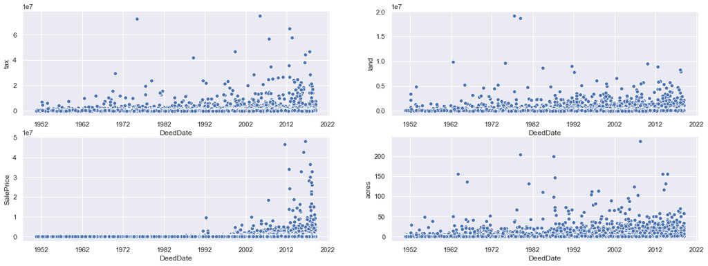

```python
#we can see how values have been trending over time by using the deed date
fig, ax  =plt.subplots(2,2, figsize = (20,7))
sns.scatterplot(x = 'DeedDate', y = 'tax',       data = data[data['DeedDate'] >  '1950-09-02'], ax = ax[0,0])
sns.scatterplot(x = 'DeedDate', y = 'land',      data = data[data['DeedDate'] >  '1950-09-02'], ax = ax[0,1])
sns.scatterplot(x = 'DeedDate', y = 'SalePrice', data = data[data['DeedDate'] >  '1950-09-02'], ax = ax[1,0])
sns.scatterplot(x = 'DeedDate', y = 'acres',     data = data[(data['DeedDate'] > '1950-09-02') & (data['acres'] < 8_000)], ax = ax[1,1])
plt.show()
```

```python
data[['tax','land','acres','SalePrice']].describe()
```

|  | tax | land | acres | SalePrice |
| --- | --- | --- | --- | --- |
| count | 5.855600e+04 | 5.855600e+04 | 58556.000000 | 5.855600e+04 |
| mean | 3.373239e+05 | 8.839801e+04 | 1.285803 | 2.215845e+05 |
| std | 1.124052e+06 | 3.935384e+05 | 57.253969 | 1.411772e+06 |
| min | 0.000000e+00 | 0.000000e+00 | 0.000000 | 0.000000e+00 |
| 25% | 1.472000e+05 | 3.380000e+04 | 0.200000 | 0.000000e+00 |
| 50% | 2.186000e+05 | 4.730000e+04 | 0.400000 | 7.500000e+04 |
| 75% | 3.263000e+05 | 8.010000e+04 | 0.870000 | 2.180000e+05 |
| max | 7.502120e+07 | 6.912000e+07 | 13824.000000 | 4.810000e+07 |

```python
#Below is a quick method for find the density of parcels with column values above or below the mean
def kde_col_plot(column):
    mean = data[column].mean()
    g1 = sns.jointplot(x="lon", y="lat", data=data[data[column] >= mean], kind="kde", color="g")
    g2 = sns.jointplot(x="lon", y="lat", data=data[data[column] <= mean], kind="kde", color="r")

    fig = plt.figure(figsize=(15,5))
    gs = gridspec.GridSpec(1, 2)

    mg1 = SeabornFig2Grid(g1, fig, gs[0])
    mg2 = SeabornFig2Grid(g2, fig, gs[1])

    gs.tight_layout(fig)
    #gs.update(top=0.7)

    return plt.show()
```

These kde plots can be useful when we pass a filtered data frame so we can look at the density of parcels that meet any criteria we wish based on the information we have. The plots below show the density of parcels when values above (green) and below (red) there respective means. For example when looking at the kde plots for acres you can tell that there is a peak in the center for parcels that are below the mean I believe that this is because a lot of the small parcels are at the center of the city.

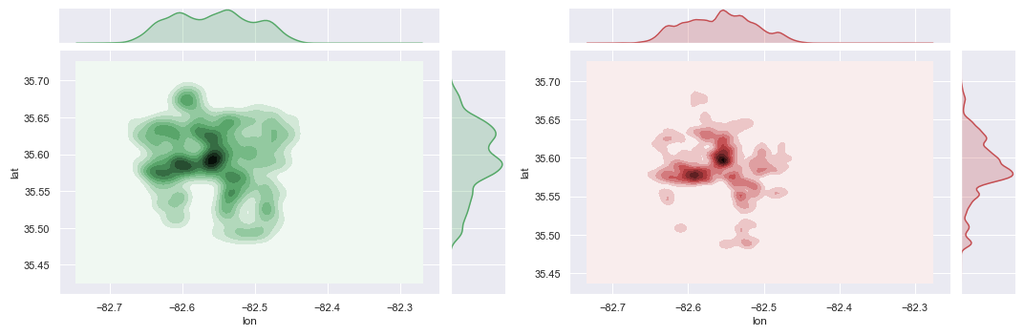

```python
kde_col_plot('acres')
```

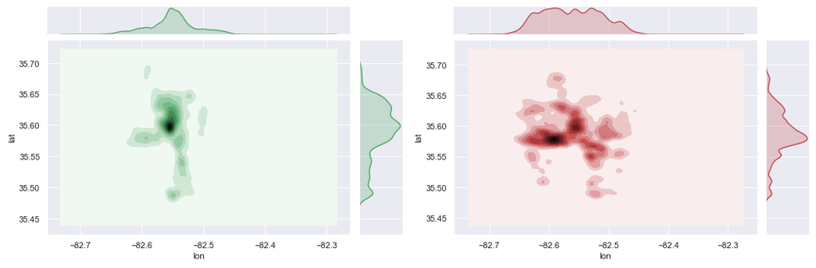

```python
kde_col_plot('tax')
```

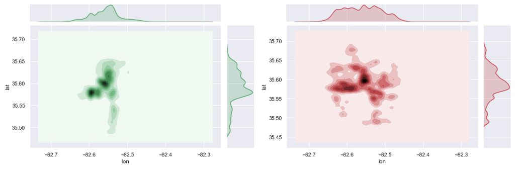

```python
kde_col_plot('land')
```

As a quick demonstration let's compare the properties owned by the city of Asheville to those of Buncombe County. This project is ongoing.

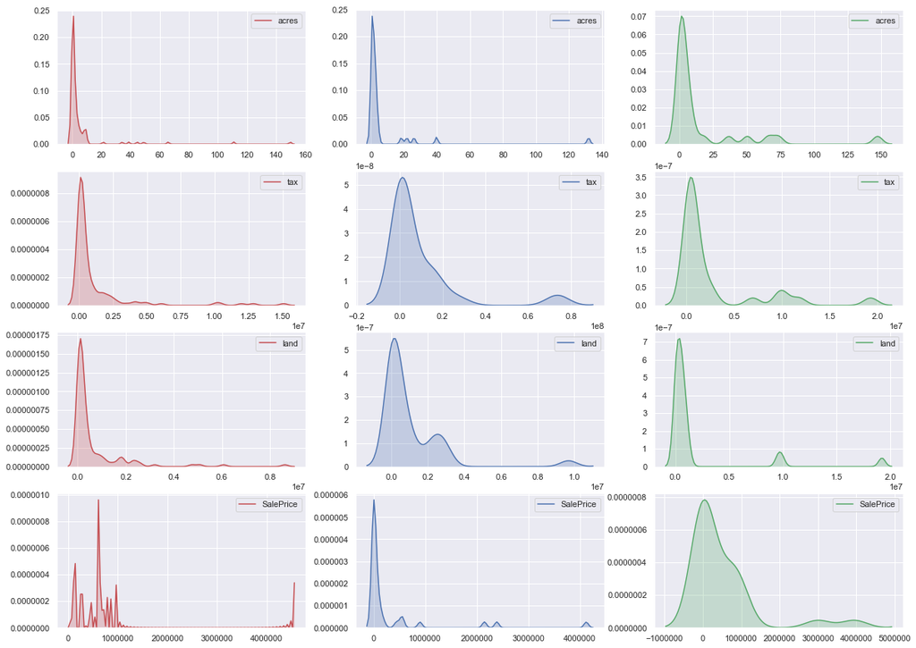

```python
city_data = data[data['owner'] == 'CITY OF ASHEVILLE']
county_data = data[data['owner'] == 'BUNCOMBE COUNTY']
state_data = data[data['owner'] == 'STATE OF NORTH CAROLINA']

fig, ax  =plt.subplots(4,3, figsize = (20,15))

sns.kdeplot(city_data.acres, ax = ax[0,0], shade=True, color="r")
sns.kdeplot(county_data.acres, ax = ax[0,1], shade=True, color="b")
sns.kdeplot(state_data.acres, ax = ax[0,2], shade=True, color="g")

sns.kdeplot(city_data.tax, ax = ax[1,0], shade=True, color="r")
sns.kdeplot(county_data.tax, ax = ax[1,1], shade=True, color="b")
sns.kdeplot(state_data.tax, ax = ax[1,2], shade=True, color="g")

sns.kdeplot(city_data.land, ax = ax[2,0], shade=True, color="r")
sns.kdeplot(county_data.land, ax = ax[2,1], shade=True, color="b")
sns.kdeplot(state_data.land, ax = ax[2,2], shade=True, color="g")

sns.kdeplot(city_data.SalePrice, ax = ax[3,0], shade=True, color="r")
sns.kdeplot(county_data.SalePrice, ax = ax[3,1], shade=True, color="b")
sns.kdeplot(state_data.SalePrice, ax = ax[3,2], shade=True, color="g")

plt.show()
```

```python
#map to label property owners
m = folium.Map(list(city_data[['lat','lon']].iloc[0]), zoom_start=13)

# mark each station as a point
for index, row in city_data.iterrows():
    folium.Marker([row['lat'], row['lon']],
                        icon=folium.Icon(color='red'),
                        popup=row['owner'],
                       ).add_to(m)

# mark each station as a point
for index, row in county_data.iterrows():
    folium.Marker([row['lat'], row['lon']],
                        icon=folium.Icon(color='blue'),
                        popup=row['owner'],
                       ).add_to(m)

# mark each station as a point
for index, row in state_data.iterrows():
    folium.Marker([row['lat'], row['lon']],
                        icon=folium.Icon(color='green'),
                        popup=row['owner'],
                       ).add_to(m)
m
```

[interactive chart not shown]

```python
df = data[(data['owner'] == 'CITY OF ASHEVILLE') ^ (data['owner'] == 'BUNCOMBE COUNTY') ^ (data['owner'] == 'STATE OF NORTH CAROLINA')]
df = df[(df.acres != 0) & (df.tax != 0) & (df.land != 0)]
df = df.reset_index(drop = True)
df.head(5)
```

|  | id | owner | acres | tax | land | building | SalePrice | DeedDate | neigh | lon | lat |
| --- | --- | --- | --- | --- | --- | --- | --- | --- | --- | --- | --- |
| 0 | 8762-81-0868-00000 | BUNCOMBE COUNTY | 2.15 | 950700.0 | 34600.0 | 914300 | 0.0 | 1989-02-14 | R8RB | -82.613310 | 35.574287 |
| 1 | 9607-43-8982-00000 | BUNCOMBE COUNTY | 0.48 | 13400.0 | 13400.0 | 0 | 71000.0 | 1997-10-29 | SLPS | -82.545166 | 35.607334 |
| 2 | 9607-43-9825-00000 | BUNCOMBE COUNTY | 0.30 | 12500.0 | 12500.0 | 0 | 50500.0 | 1997-12-19 | SLPS | -82.545140 | 35.607307 |
| 3 | 9607-43-9880-00000 | BUNCOMBE COUNTY | 0.37 | 12900.0 | 12900.0 | 0 | 49500.0 | 1997-12-10 | SLPS | -82.545130 | 35.607285 |
| 4 | 9607-44-7065-00000 | BUNCOMBE COUNTY | 0.22 | 12000.0 | 12000.0 | 0 | 13000.0 | 1997-10-29 | SLPS | -82.545230 | 35.607390 |

```python
df.owner.value_counts()
```

```
CITY OF ASHEVILLE          124
BUNCOMBE COUNTY             36
STATE OF NORTH CAROLINA     25
Name: owner, dtype: int64
```

```python
df[['owner','acres','tax','land','SalePrice']].groupby('owner').sum()
```

| owner | acres | tax | land | SalePrice |
| --- | --- | --- | --- | --- |
| BUNCOMBE COUNTY | 284.259999 | 325447700.0 | 36796600.0 | 11934000.0 |
| CITY OF ASHEVILLE | 748.689988 | 131998000.0 | 79311900.0 | 8923150.0 |
| STATE OF NORTH CAROLINA | 449.719993 | 73566300.0 | 49569600.0 | 13882450.0 |

```python
df[['owner','acres','tax','land','SalePrice']].groupby('owner').mean()
```

| owner | acres | tax | land | SalePrice |
| --- | --- | --- | --- | --- |
| BUNCOMBE COUNTY | 7.896111 | 9.040214e+06 | 1.022128e+06 | 331500.000000 |
| CITY OF ASHEVILLE | 6.037822 | 1.064500e+06 | 6.396121e+05 | 71960.887097 |
| STATE OF NORTH CAROLINA | 17.988800 | 2.942652e+06 | 1.982784e+06 | 555298.000000 |

# Resources

[Merging Dataframes](https://www.shanelynn.ie/merge-join-dataframes-python-pandas-index-1/)

[Predicting Prices](http://fastml.com/predicting-sales-pandas-vs-sql/)

[SQL vs Pandas](https://medium.com/carwow-product-engineering/sql-vs-pandas-how-to-balance-tasks-between-server-and-client-side-9e2f6c95677)